# Exploring Bank Visits

[figure not shown]

[figure not shown]

[figure not shown]

[figure not shown]

[figure not shown]

[figure not shown]

This **exploratory analysis** aims to shed some light on customers making withdrawals and deposits at tellers.

The **goal** is to be able to uncover reasons for using this particular banking channel which will ultimately assist the bank in migrating their customers to digital channels.

### **Teller Transaction Trends**

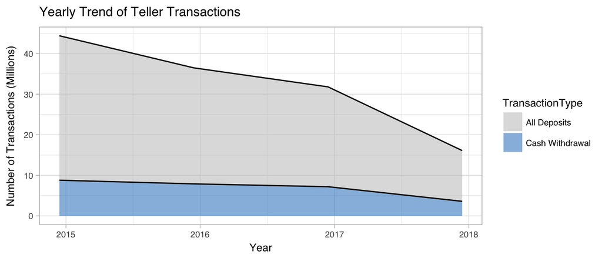

- There is a clear **decreasing** trend in the amount of teller transactions over the last few years.
- With the rise in digital and ATM capabilities, there is a movement towards these channels instead and a decline in teller visits.
- However, there are still a number of transactions still being made at the bank teller.

In the next few slides, we will look into these teller transactions…

### **When are Customers Transacting at Tellers?**

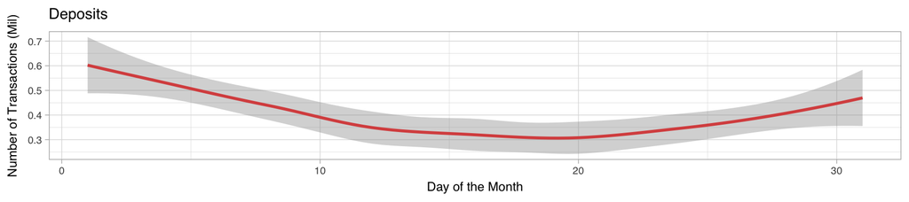

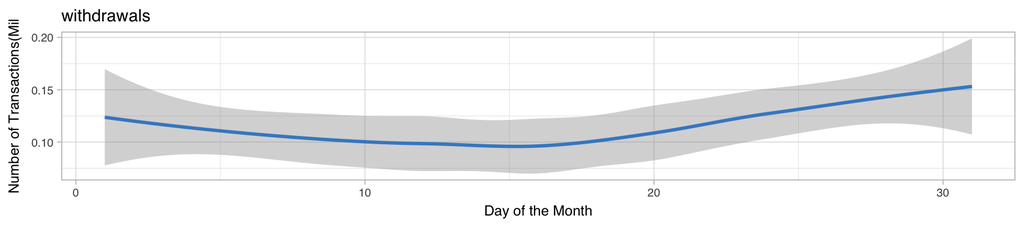

**Plot of the number of transactions for 2017 for each day of the month, for both withdrawals and deposits.**

Having an understanding of **when** customers visit bank tellers to deposit or withdraw money, could explain **why** they preferred visting the bank rather than using an ATM.

- **For deposits** there are peaks in the first and last 10 days of the month. This could indicate customers who receive their monthly salary in cash and deposit it during this period.
- **For withdrawals** there is a large peak during the last 10 days of the month. This suggests customers who may have cash payments due at the end of the month.
- In order to confirm that customers are mainly using tellers to deposit their monthly pay, next we look at **repeated transaction amounts**.

### **Repeated Transactions**

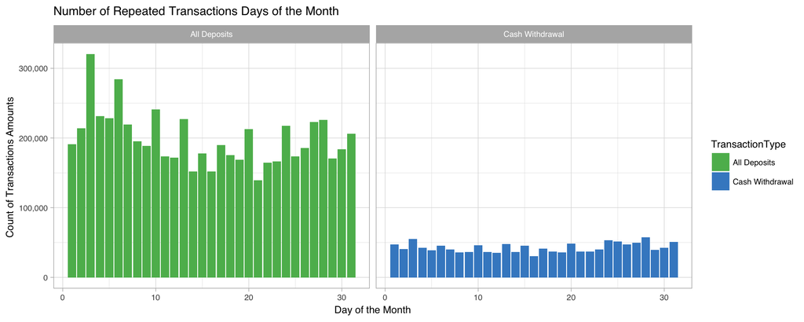

**Number of Transactions on specific Days :** A look at the number of customers making deposits and withdrawals of the same amount at specific days of the month. This confirms:

- Peak in deposits at the beginning of the month is mostly customer’s depositing their **salaries**.
- The highest repeated deposit is on **day 3** of the month.
- There are high number of repeated withdrawals at the end of the month.

**Next Questions to Look at:**

- Why do customers prefer to deposit their pay at tellers?
- Are they depositing big amounts and they would rather do this at the teller?
- Or, do they find using tellers easier than ATM’s as they have not adopted to the technology?

### **Transaction Amounts**

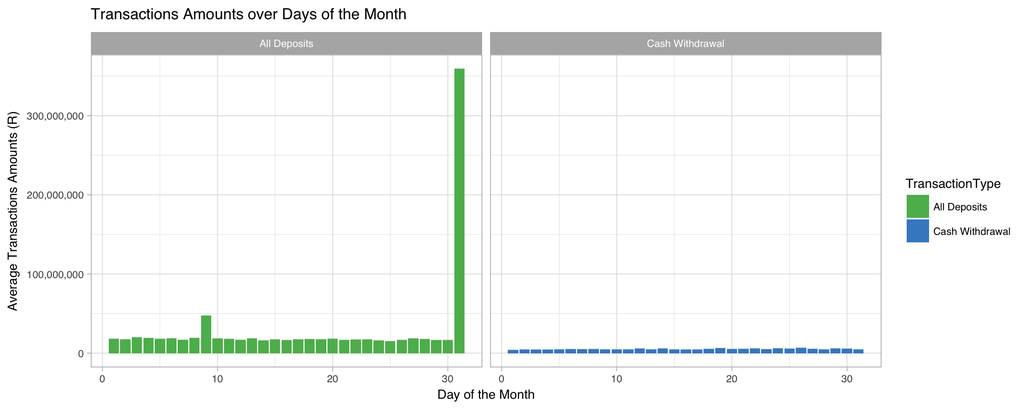

**Distribution of Transaction amounts**

### **Teller & ATM Customer Profiles**

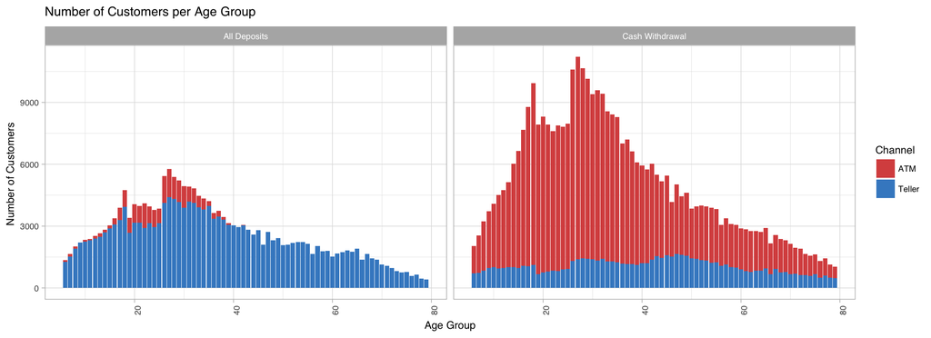

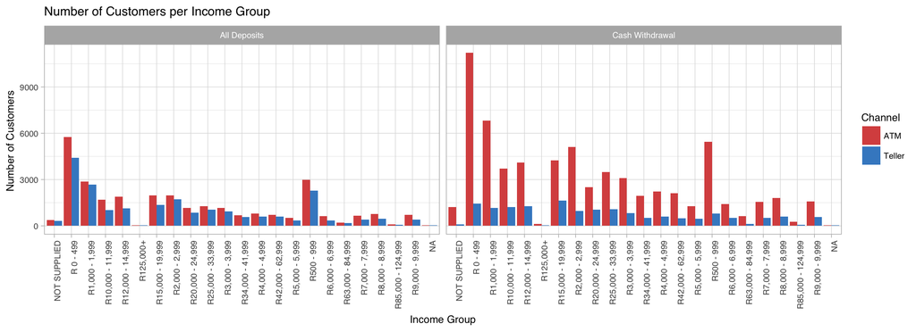

**Plots of Customer Demographics**

### **Teller & ATM Customer’s Banking Segments**

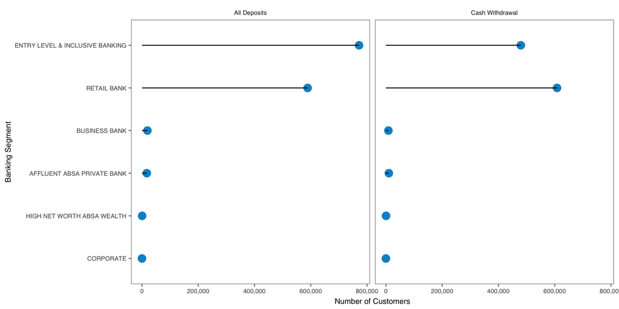

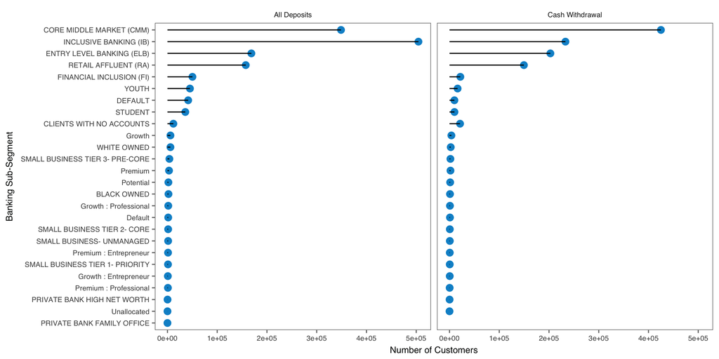

### **Where are Customers visting Tellers?**

[interactive chart not shown]

**Click** on circles to see specific teller information. The size of the circle indicates customer traffic at the particular teller.

**Zoom** in on the map to see specific areas.

### **Conculsion & Future Work**

**Conclusion from this Analysis**

- Customers mostly use tellers to deposit their monthly pay check.
- Older customers prefer using tellers, suggesting they familiar and comfortable using tellers and haven’t adopted to ATM’s yet.
- Customers from the Entry level banking and Retail banking segments are predominently using Tellers.

In order to give **actionable** insights to the bank, a dashboard should be developed to do the following:

- Give insight into repeated transaction amounts deposited or withdrawn.
- Identify which tellers are these repeat transactions being done at and which ATM’s in the surrounding areas can fulfil these customer requests.
- If there is a withdrawal or deposit limit at the nearest ATM’s, the bank should be aware of this so that they can take action to make these transactions easier for customers.
- The tool should inform the bank which customers prefer tellers over ATM’s, so that the appropriate and relevant marketing information about other channels can be shared with the customer.